# Reproducible Workflow Code

Jordan Melson

2023-04-17

## Code

The data for this project is 8 weeks worth of crape myrtle bark scale population counts from CMBS infested crape myrtles in the greenhouse. Adult and Crawler counts were taken weekly over 2 months on 36 trees with 6 different treatments. All data are physical, in-situ counts, taken by hand. CMBS adults and crawlers were counted on 10 cm of 3 random branches. The goal of the experiment was to determine if limonene, a botanical, had similar or better control of CMBS than common chemical insecticides including pyriproxyfen, dinotefuran, and imidacloprid, as well as a water treatment and a non-treated control. Based on previous unpublished data, we hypothesize that limonene will meet or exceed our expectations for the control of CMBS.

```r
library(tidyverse)
library(emmeans)
library(multcomp)
library(multcompView)

LimoR <- read.csv('LimoR.csv')

anova(lm(Total~Trt, data = LimoR))
```

```
## Analysis of Variance Table
##
## Response: Total
##            Df   Sum Sq Mean Sq F value    Pr(>F)
## Trt         5  2434578  486916  4.4661 0.0006016 ***
## Residuals 318 34669696  109024
## ---
## Signif. codes:  0 '***' 0.001 '**' 0.01 '*' 0.05 '.' 0.1 ' ' 1
```

```r
lm.trt <- lm(Total ~ Trt, data = LimoR)
summary(lm.trt)
```

```
##
## Call:
## lm(formula = Total ~ Trt, data = LimoR)
##
## Residuals:
##     Min      1Q  Median      3Q     Max
## -371.19 -230.66  -97.53  165.90 1435.59
##
## Coefficients:
##             Estimate Std. Error t value Pr(>|t|)
## (Intercept)   355.93      44.93   7.921 3.98e-14 ***
## TrtDino      -118.52      63.54  -1.865  0.06309 .
## TrtImid        12.76      63.54   0.201  0.84099
## TrtLimo      -224.56      63.54  -3.534  0.00047 ***
## TrtPyri        15.26      63.54   0.240  0.81038
## TrtWater      -72.13      63.54  -1.135  0.25719
## ---
## Signif. codes:  0 '***' 0.001 '**' 0.01 '*' 0.05 '.' 0.1 ' ' 1
##
## Residual standard error: 330.2 on 318 degrees of freedom
## Multiple R-squared:  0.06561,    Adjusted R-squared:  0.05092
## F-statistic: 4.466 on 5 and 318 DF,  p-value: 0.0006016
```

```r
lsmeans <- emmeans(lm.trt, ~Trt)

Results_lsmeans <- multcomp::cld(lsmeans, alpha = 0.05, reversed = TRUE, details = TRUE)
Results_lsmeans
```

```
## $emmeans
##  Trt     emmean   SE  df lower.CL upper.CL .group
##  Pyri       371 44.9 318      283      460  1
##  Imid       369 44.9 318      280      457  1
##  Control    356 44.9 318      268      444  1
##  Water      284 44.9 318      195      372  12
##  Dino       237 44.9 318      149      326  12
##  Limo       131 44.9 318       43      220   2
##
## Confidence level used: 0.95
## P value adjustment: tukey method for comparing a family of 6 estimates
## significance level used: alpha = 0.05
## NOTE: If two or more means share the same grouping symbol,
##       then we cannot show them to be different.
##       But we also did not show them to be the same.
##
## $comparisons
##  contrast        estimate   SE  df t.ratio p.value
##  Dino - Limo        106.0 63.5 318   1.669  0.5536
##  Water - Limo       152.4 63.5 318   2.399  0.1598
##  Water - Dino        46.4 63.5 318   0.730  0.9781
##  Control - Limo     224.6 63.5 318   3.534  0.0062
##  Control - Dino     118.5 63.5 318   1.865  0.4257
##  Control - Water     72.1 63.5 318   1.135  0.8664
##  Imid - Limo        237.3 63.5 318   3.735  0.0030
##  Imid - Dino        131.3 63.5 318   2.066  0.3080
##  Imid - Water        84.9 63.5 318   1.336  0.7648
##  Imid - Control      12.8 63.5 318   0.201  1.0000
##  Pyri - Limo        239.8 63.5 318   3.774  0.0026
##  Pyri - Dino        133.8 63.5 318   2.105  0.2872
##  Pyri - Water        87.4 63.5 318   1.375  0.7419
##  Pyri - Control      15.3 63.5 318   0.240  0.9999
##  Pyri - Imid          2.5 63.5 318   0.039  1.0000
##
## P value adjustment: tukey method for comparing a family of 6 estimates
```

```r
anova <- aov(Total ~ Trt, data = LimoR)
tukey <- TukeyHSD(anova)
cld <- multcompLetters4(anova,tukey)

dt <- group_by(LimoR, Trt) %>%
  summarise(w=mean(Total), sd = sd(Total)) %>%
  arrange(desc(w))

cld <- as.data.frame.list(cld$Trt)
dt$cld <- cld$Letters

print(dt)
```

```
## # A tibble: 6 × 4
##   Trt         w    sd cld
##   <chr>   <dbl> <dbl> <chr>
## 1 Pyri     371.  463. a
## 2 Imid     369.  390. a
## 3 Control  356.  281. a
## 4 Water    284.  263. ab
## 5 Dino     237.  292. ab
## 6 Limo     131.  232. b
```

## Analysis

Treatment did have a significant effect on the total number of CMBS on the crape myrtles (p=0.0006). Limonene is not significantly different from dinotefuran or water but is the only of those treatments that is significantly different from the other treatments (imidacloprid, pyriproxyfen, and control).

```
## No summary function supplied, defaulting to `mean_se()`
```

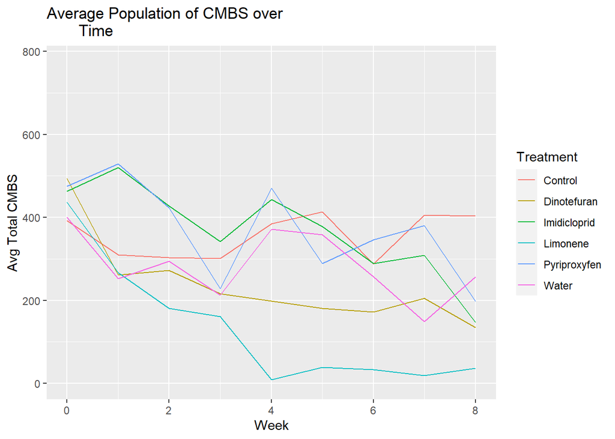

```r
library(ggplot2)
LC <- scale_color_discrete(name="Treatment",
                         breaks=c("Control", "Dino", "Imid", "Limo", "Pyri",
                                  "Water"),
                         labels=c("Control", "Dinotefuran", "Imidicloprid",
                                  "Limonene", "Pyriproxyfen", "Water"))

ggplot(LimoR, aes(x = Date, y = Total, group = Trt, color = Trt)) +
  stat_summary(geom ="line")+
  labs(x = "Week", y = "Avg Total CMBS", title = "Average Population of CMBS over
       Time")+
  LC
```

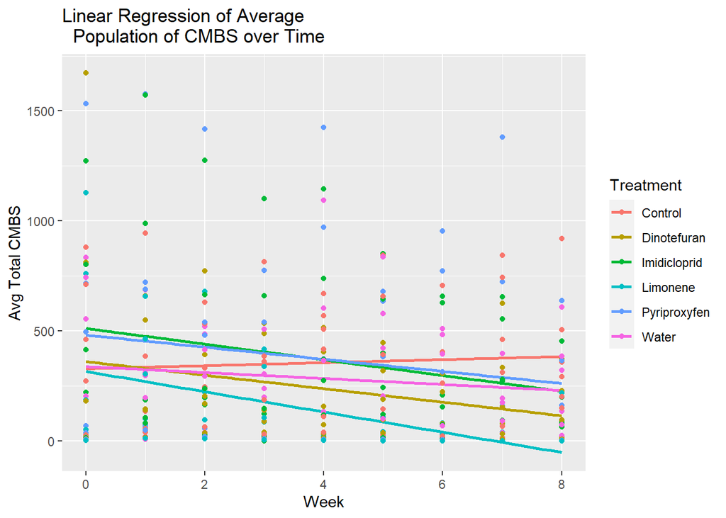

```r
ggplot(LimoR, aes(x = Date, y = Total, group = Trt, color = Trt)) +
  geom_smooth(method = lm, se = FALSE)+
  geom_point()+
  labs(x = "Week", y = "Avg Total CMBS", title = "Linear Regression of Average
  Population of CMBS over Time")+
  LC
```

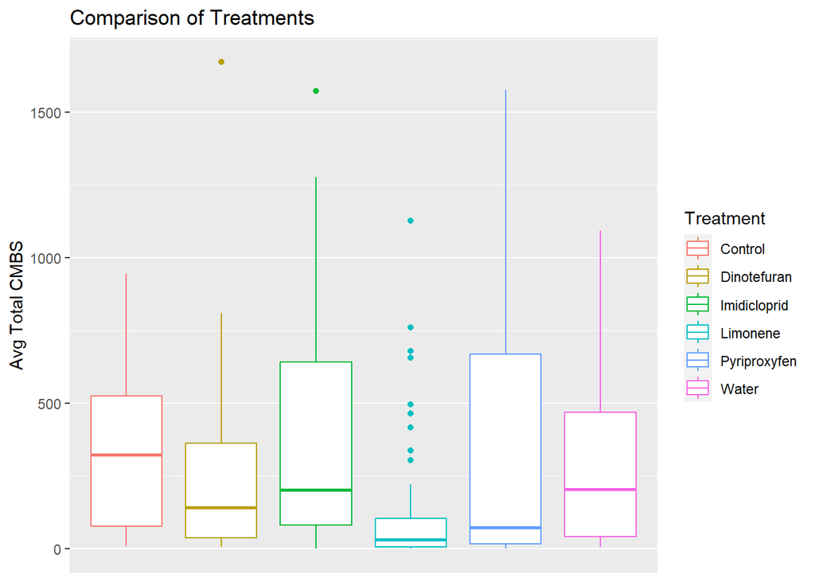

```r
ggplot(LimoR, aes(x = Trt, y = Total, group = Trt, color = Trt)) +
  geom_boxplot()+
  scale_x_discrete(breaks=NULL)+
  labs(x= NULL, y = "Avg Total CMBS", title = "Comparison of Treatments")+
  LC
```

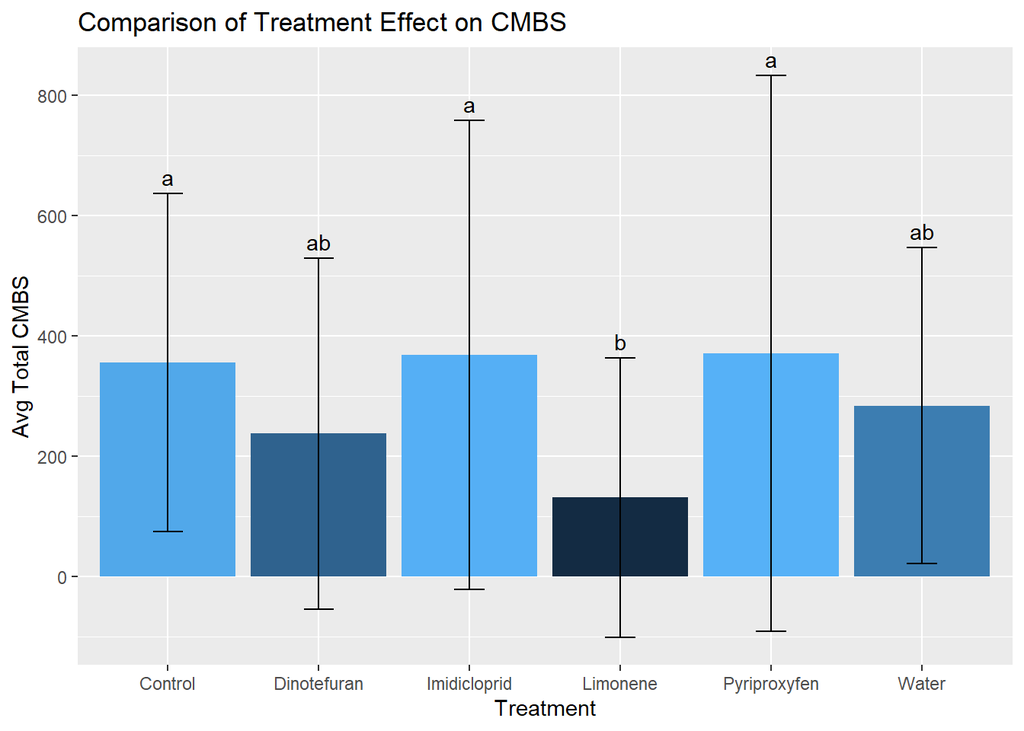

```r
ggplot(dt, aes(Trt, w)) +
  geom_bar(stat = "identity", aes(fill = w), show.legend = FALSE)+
  geom_errorbar(aes(ymin = w-sd, ymax = w+sd), width = 0.2)+
  labs(x = "Treatment", y = "Avg Total CMBS", title = "Comparison of Treatment Effect on CMBS")+
  geom_text(aes(label = cld, y = w + sd), vjust = -0.5) +
  scale_x_discrete(breaks=c("Control", "Dino", "Imid", "Limo", "Pyri",
                                  "Water"),
                         labels=c("Control", "Dinotefuran", "Imidicloprid",
                                  "Limonene", "Pyriproxyfen", "Water"))
```